# Distributional analyses of child/adult turn taking (Lindsay et al, Experiment 2)

Hugh Rabagliati

12/15/2016

# 1 Background

In this study, children and adults answered questions while playing an iPad game. We varied

- Whether the context of the question made it possible to predict the answer (factor Pred/Unpred).
- Whether the form of the question made it possible to predict the answer (factor Early/Late).
- The interaction of these two factors (i.e., a proper test of whether participants predict during conversation).
- Whether the answer to the question was Yes/No (to ensure that participants’ attend to the questions).

In this analysis, we fit hierarchical Bayesian models to characterize the distribution of reaction times

## 1.1 Distribution of Respose Times

The graphs below show the distribution of normaliszed RTs across conditions (we exclude trials where participants were incorrect, and participants who produced fewer than 20 datapoints). When information comes early, adults respond reliably faster in predictable contexts (see non-distributional analyses). It is not clear if the same is true for children.

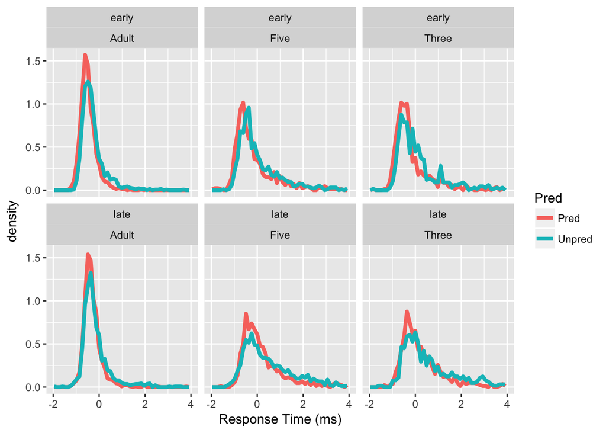

# 2 Analysis

An ex-gaussian distribution convolves a normal distribution with an exponential – this gives it a long and heavy right tail. We aimed to fit an ex-Gaussian to the response time data, comparing adults with children, and hierarchically modeling the mu parameter, the sigma parameter, and the tau parameter. Mu is the mean of the normal and sigma its standard deviation, while tau is the rate of the exponential. We modeled how these varied across conditions, accounting for random subjec intercepts. Informally, our model had the form:

Mu ~ B0 + (B1 * Early) + (B2 * Pred) + (B3 * Right/Wrong) + (B4 * Age) + … (the full set of interactions) + (1|Subject)  
Sigma ~ B0 + (B1 * Early) + (B2 * Pred) + (B3 * Right/Wrong)+ (B4 * Age) + … (the full set of interactions) + (1|Subject)  
Tau ~ B0 + (B1 * Early) + (B2 * Pred) + (B3 * Right/Wrong) + (B4 * Age) + … (the full set of interactions) + (1|Subject)

Initially, this did not converge well. But it converged much better once we added bounded beta priors on the prior for the SD for the by subjects intercepts. We followed up with individual group analyses.

## 2.1 Whole group analysis

```r
age_factors <- c("mu_intercept","mu_Match","mu_Pred","mu_Right","mu_Fives","mu_Threes",
                    "mu_MatchByPred","mu_MatchByFives","mu_MatchByThrees","mu_PredByFives","mu_PredByThrees",
                    "mu_MatchByPredByFives","mu_MatchByPredByThrees",
                    "sig_intercept","sig_Match","sig_Pred","sig_Right","sig_Fives","sig_Threes",
                    "sig_MatchByPred","sig_MatchByFives","sig_MatchByThrees","sig_PredByFives","sig_PredByThrees",
                    "sig_MatchByPredByFives","sig_MatchByPredByThrees",
                    "tau_intercept","tau_Match","tau_Pred","tau_Right","tau_Fives","tau_Threes",
                    "tau_MatchByPred","tau_MatchByFives","tau_MatchByThrees","tau_PredByFives","tau_PredByThrees",
                    "tau_MatchByPredByFives","tau_MatchByPredByThrees")


stanDat_full <- list(rt = tt$rt,
                     factor1 = tt$N_Early,
                     factor2 = tt$N_Pred,
                     factor3 = tt$N_Right,
                     factor4 = tt$N_AgeFive,
                     factor5 = tt$N_AgeThree,
                     factor6 = tt$N_E_P_Interact,
                     factor7 = tt$N_Early_AgeFive_Interact,
                     factor7a = tt$N_Early_AgeThree_Interact,
                     factor8 = tt$N_Pred_AgeFive_Interact,
                     factor8a = tt$N_Pred_AgeThree_Interact,
                     factor9 = tt$N_Early_Pred_AgeFive_Interact,
                     factor9a = tt$N_Early_Pred_AgeThree_Interact,
                     N = nrow(tt), J = nlevels(as.factor(tt$Subject)), Subj = as.integer(as.factor(tt$Subject)))

eg_stan_exp <- stan(file="fixEf_AllAges_and_Conds_transf_expt2_beta.stan",
                    data=stanDat_full,
                    chains = 3, iter = 50,  control = list(adapt_delta = 0.88))
all.summary <- summary(eg_stan_exp, pars = c("beta0","beta","beta_s0","beta_s","beta_t0","beta_t"), probs = c(0.025,0.5,0.975))$summary

kable(data.frame("Params" = age_factors,all.summary), digits = 2)
```

|  | Params | mean | se_mean | sd | X2.5. | X50. | X97.5. | n_eff | Rhat |
| --- | --- | --- | --- | --- | --- | --- | --- | --- | --- |
| beta0 | mu_intercept | -0.72 | 0.00 | 0.04 | -0.78 | -0.72 | -0.65 | 75.00 | 1.02 |
| beta[1] | mu_Match | 0.11 | 0.00 | 0.01 | 0.09 | 0.11 | 0.13 | 75.00 | 1.04 |
| beta[2] | mu_Pred | 0.09 | 0.01 | 0.05 | 0.01 | 0.09 | 0.19 | 75.00 | 1.01 |
| beta[3] | mu_Right | 0.04 | 0.00 | 0.01 | 0.03 | 0.04 | 0.04 | 75.00 | 1.01 |
| beta[4] | mu_Fives | -0.11 | 0.01 | 0.05 | -0.20 | -0.11 | -0.02 | 75.00 | 1.00 |
| beta[5] | mu_Threes | -0.13 | 0.01 | 0.05 | -0.22 | -0.13 | -0.05 | 55.74 | 1.02 |
| beta[6] | mu_MatchByPred | -0.05 | 0.00 | 0.02 | -0.08 | -0.05 | -0.01 | 74.26 | 1.06 |
| beta[7] | mu_MatchByFives | 0.12 | 0.00 | 0.02 | 0.07 | 0.12 | 0.15 | 75.00 | 1.02 |
| beta[8] | mu_MatchByThrees | 0.15 | 0.00 | 0.03 | 0.10 | 0.15 | 0.20 | 75.00 | 0.98 |
| beta[9] | mu_PredByFives | -0.02 | 0.01 | 0.05 | -0.12 | -0.02 | 0.08 | 75.00 | 0.98 |
| beta[10] | mu_PredByThrees | 0.01 | 0.01 | 0.06 | -0.09 | 0.01 | 0.11 | 75.00 | 1.01 |
| beta[11] | mu_MatchByPredByFives | 0.01 | 0.00 | 0.04 | -0.05 | 0.01 | 0.10 | 75.00 | 0.97 |
| beta[12] | mu_MatchByPredByThrees | -0.02 | 0.00 | 0.04 | -0.08 | -0.02 | 0.06 | 75.00 | 1.01 |
| beta_s0 | sig_intercept | -2.06 | 0.02 | 0.09 | -2.25 | -2.07 | -1.90 | 29.24 | 1.04 |
| beta_s[1] | sig_Match | 0.31 | 0.01 | 0.07 | 0.19 | 0.31 | 0.44 | 75.00 | 0.96 |
| beta_s[2] | sig_Pred | 0.02 | 0.01 | 0.10 | -0.15 | 0.00 | 0.21 | 59.17 | 1.07 |
| beta_s[3] | sig_Right | -0.13 | 0.01 | 0.04 | -0.20 | -0.13 | -0.05 | 42.24 | 1.07 |
| beta_s[4] | sig_Fives | 0.06 | 0.02 | 0.12 | -0.18 | 0.06 | 0.25 | 53.04 | 1.06 |
| beta_s[5] | sig_Threes | 0.16 | 0.01 | 0.11 | -0.03 | 0.15 | 0.39 | 63.55 | 1.03 |
| beta_s[6] | sig_MatchByPred | 0.10 | 0.01 | 0.09 | -0.07 | 0.09 | 0.26 | 75.00 | 1.00 |
| beta_s[7] | sig_MatchByFives | 0.03 | 0.01 | 0.09 | -0.13 | 0.03 | 0.19 | 75.00 | 0.99 |
| beta_s[8] | sig_MatchByThrees | 0.06 | 0.01 | 0.12 | -0.21 | 0.06 | 0.27 | 75.00 | 1.00 |
| beta_s[9] | sig_PredByFives | 0.11 | 0.01 | 0.13 | -0.12 | 0.10 | 0.35 | 75.00 | 0.97 |
| beta_s[10] | sig_PredByThrees | 0.05 | 0.02 | 0.13 | -0.21 | 0.05 | 0.30 | 52.80 | 1.00 |
| beta_s[11] | sig_MatchByPredByFives | 0.15 | 0.02 | 0.14 | -0.08 | 0.15 | 0.50 | 64.45 | 0.99 |
| beta_s[12] | sig_MatchByPredByThrees | 0.02 | 0.01 | 0.12 | -0.22 | 0.02 | 0.24 | 75.00 | 0.97 |
| beta_t0 | tau_intercept | -1.35 | 0.02 | 0.14 | -1.59 | -1.37 | -1.08 | 44.93 | 1.05 |
| beta_t[1] | tau_Match | 0.28 | 0.01 | 0.07 | 0.17 | 0.28 | 0.41 | 75.00 | 0.99 |
| beta_t[2] | tau_Pred | 0.16 | 0.02 | 0.15 | -0.08 | 0.15 | 0.43 | 42.71 | 1.03 |
| beta_t[3] | tau_Right | 0.07 | 0.00 | 0.04 | 0.01 | 0.07 | 0.14 | 75.00 | 0.98 |
| beta_t[4] | tau_Fives | 1.24 | 0.03 | 0.19 | 0.88 | 1.25 | 1.57 | 52.50 | 1.03 |
| beta_t[5] | tau_Threes | 1.35 | 0.02 | 0.17 | 1.06 | 1.35 | 1.66 | 67.15 | 1.02 |
| beta_t[6] | tau_MatchByPred | -0.11 | 0.01 | 0.09 | -0.30 | -0.10 | 0.05 | 75.00 | 0.98 |
| beta_t[7] | tau_MatchByFives | -0.03 | 0.01 | 0.11 | -0.25 | -0.05 | 0.14 | 75.00 | 1.00 |
| beta_t[8] | tau_MatchByThrees | 0.03 | 0.01 | 0.12 | -0.16 | 0.03 | 0.22 | 75.00 | 0.97 |
| beta_t[9] | tau_PredByFives | 0.19 | 0.03 | 0.21 | -0.24 | 0.20 | 0.58 | 66.28 | 1.01 |
| beta_t[10] | tau_PredByThrees | 0.32 | 0.03 | 0.26 | -0.22 | 0.34 | 0.78 | 75.00 | 0.97 |
| beta_t[11] | tau_MatchByPredByFives | 0.22 | 0.02 | 0.14 | -0.04 | 0.21 | 0.48 | 75.00 | 0.97 |
| beta_t[12] | tau_MatchByPredByThrees | 0.28 | 0.02 | 0.15 | 0.03 | 0.27 | 0.55 | 75.00 | 0.99 |

## 2.3 Ex-Gaussian Analysis of Adults

```r
tt_adult <- subset(tt, Age == "Adult")

stanDat_adult <- list(rt = tt_adult$rt,
                     factor1 = tt_adult$N_Early,
                     factor2 = tt_adult$N_Pred,
                     factor3 = tt_adult$N_Right,
                     factor4 = tt_adult$N_E_P_Interact,
                     N = nrow(tt_adult), J = nlevels(as.factor(tt_adult$Subject)), Subj = as.integer(as.factor(tt_adult$Subject)))

adult_model <- stan(file="fixEf_Conds_transf_expt2.stan",
                    data=stanDat_adult,
                    chains = 2, iter = 150,  control = list(adapt_delta = 0.95))
```

```r
no_age_factors <- c("mu_intercept","mu_Match","mu_Pred","mu_Right","mu_MatchByPred",
                    "sig_intercept","sig_Match","sig_Pred","sigma_Right","sig_MatchByPred",
                    "tau_intercept","tau_Match","tau_Pred","tau_Right","tau_MatchByPred")

adult.summary <- summary(adult_model, pars = c("beta0","beta","beta_s0","beta_s","beta_t0","beta_t"), probs = c(0.025,0.5,0.975))$summary

kable(data.frame("Params" = no_age_factors,adult.summary), digits = 2)
```

|  | Params | mean | se_mean | sd | X2.5. | X50. | X97.5. | n_eff | Rhat |
| --- | --- | --- | --- | --- | --- | --- | --- | --- | --- |
| beta0 | mu_intercept | -0.69 | 0.00 | 0.04 | -0.75 | -0.69 | -0.61 | 150.00 | 1.00 |
| beta[1] | mu_Match | 0.11 | 0.00 | 0.01 | 0.08 | 0.11 | 0.13 | 150.00 | 0.99 |
| beta[2] | mu_Pred | 0.07 | 0.00 | 0.05 | -0.02 | 0.06 | 0.16 | 150.00 | 1.00 |
| beta[3] | mu_Right | 0.02 | 0.00 | 0.01 | 0.01 | 0.02 | 0.04 | 150.00 | 1.00 |
| beta[4] | mu_MatchByPred | -0.05 | 0.00 | 0.02 | -0.08 | -0.05 | -0.02 | 89.76 | 0.99 |
| beta_s0 | sig_intercept | -2.11 | 0.01 | 0.09 | -2.30 | -2.11 | -1.97 | 130.19 | 0.99 |
| beta_s[1] | sig_Match | 0.37 | 0.01 | 0.08 | 0.24 | 0.38 | 0.51 | 150.00 | 1.01 |
| beta_s[2] | sig_Pred | 0.02 | 0.01 | 0.12 | -0.18 | 0.02 | 0.29 | 105.46 | 1.02 |
| beta_s[3] | sigma_Right | -0.14 | 0.00 | 0.05 | -0.23 | -0.14 | -0.04 | 150.00 | 1.00 |
| beta_s[4] | sig_MatchByPred | 0.06 | 0.01 | 0.10 | -0.11 | 0.06 | 0.24 | 150.00 | 1.02 |
| beta_t0 | tau_intercept | -1.49 | 0.02 | 0.12 | -1.69 | -1.50 | -1.27 | 38.76 | 1.06 |
| beta_t[1] | tau_Match | 0.27 | 0.01 | 0.08 | 0.13 | 0.26 | 0.40 | 150.00 | 1.01 |
| beta_t[2] | tau_Pred | 0.19 | 0.04 | 0.16 | -0.10 | 0.19 | 0.47 | 18.29 | 1.09 |
| beta_t[3] | tau_Right | 0.13 | 0.00 | 0.05 | 0.03 | 0.13 | 0.22 | 95.91 | 1.02 |
| beta_t[4] | tau_MatchByPred | -0.10 | 0.01 | 0.10 | -0.28 | -0.09 | 0.07 | 150.00 | 1.00 |

## 2.4 Ex-Gaussian Analysis of Kids

```r
tt_kids <- subset(tt, Age != "Adult")

stanDat_kids <- list(rt = tt_kids$rt,
                     factor1 = tt_kids$N_Early,
                     factor2 = tt_kids$N_Pred,
                     factor3 = tt_kids$N_Right,
                     factor4 = tt_kids$N_E_P_Interact,
                     N = nrow(tt_kids), J = nlevels(as.factor(tt_kids$Subject)), Subj = as.integer(as.factor(tt_kids$Subject)))

kid_model <- stan(file="fixEf_Conds_transf_expt2.stan",
                    data=stanDat_kids,
                    chains = 2, iter = 150,  control = list(adapt_delta = 0.95))
```

```r
kid.summary <- summary(kid_model, pars = c("beta0","beta","beta_s0","beta_s","beta_t0","beta_t"), probs = c(0.025,0.5,0.975))$summary

kable(data.frame("Params" = no_age_factors,kid.summary), digits = 2)
```

|  | Params | mean | se_mean | sd | X2.5. | X50. | X97.5. | n_eff | Rhat |
| --- | --- | --- | --- | --- | --- | --- | --- | --- | --- |
| beta0 | mu_intercept | -0.87 | 0.00 | 0.03 | -0.91 | -0.86 | -0.81 | 150.00 | 1.00 |
| beta[1] | mu_Match | 0.24 | 0.00 | 0.02 | 0.21 | 0.24 | 0.28 | 150.00 | 1.00 |
| beta[2] | mu_Pred | 0.09 | 0.00 | 0.04 | 0.03 | 0.09 | 0.16 | 150.00 | 1.00 |
| beta[3] | mu_Right | 0.06 | 0.00 | 0.01 | 0.03 | 0.07 | 0.09 | 123.97 | 0.99 |
| beta[4] | mu_MatchByPred | -0.06 | 0.00 | 0.03 | -0.12 | -0.06 | -0.01 | 150.00 | 1.00 |
| beta_s0 | sig_intercept | -1.93 | 0.01 | 0.11 | -2.12 | -1.94 | -1.70 | 150.00 | 0.99 |
| beta_s[1] | sig_Match | 0.26 | 0.01 | 0.10 | 0.09 | 0.25 | 0.45 | 150.00 | 0.99 |
| beta_s[2] | sig_Pred | 0.04 | 0.01 | 0.14 | -0.22 | 0.03 | 0.34 | 150.00 | 1.01 |
| beta_s[3] | sigma_Right | -0.12 | 0.01 | 0.08 | -0.28 | -0.11 | 0.03 | 150.00 | 0.99 |
| beta_s[4] | sig_MatchByPred | 0.28 | 0.01 | 0.14 | 0.05 | 0.26 | 0.53 | 150.00 | 0.99 |
| beta_t0 | tau_intercept | 0.08 | 0.02 | 0.11 | -0.09 | 0.05 | 0.34 | 24.55 | 1.03 |
| beta_t[1] | tau_Match | 0.26 | 0.01 | 0.07 | 0.12 | 0.26 | 0.37 | 150.00 | 1.00 |
| beta_t[2] | tau_Pred | 0.29 | 0.02 | 0.15 | 0.00 | 0.28 | 0.58 | 48.12 | 0.99 |
| beta_t[3] | tau_Right | 0.00 | 0.00 | 0.05 | -0.10 | 0.00 | 0.09 | 150.00 | 0.99 |
| beta_t[4] | tau_MatchByPred | 0.15 | 0.01 | 0.09 | -0.03 | 0.14 | 0.35 | 150.00 | 0.99 |